# Tuning the GBM tree depth

Sidharth Gupta

```r
library(dplyr)
library(magrittr)
library(gridExtra)
library(ggplot2)
library(h2o)
library(gridExtra)
library(futile.logger)
source("h2o/source-for-rmd.R")
H2O.PORT = 54321
H2O.HOST = "localhost"  # TODO: Remote?
SEED = 123456
h2o.init()
h2o.init(ip = H2O.HOST, port = H2O.PORT)
```

## Task Description

Now that the learning rate is sort of decided we want to tune the tree depth.

Again here the only the components that are varying are shown. The code is contained in the Markdown files respectively.

## Modify the GBM depth parameters

We reuse the code from last notebook. The only part I will change is the depth parameter:

```r
set.seed(SEED)
max_depth_opts = seq(5,15)
list[search_criteria.gbm.depth, hyper_params.gbm.depth] = hyper_params_search_crit.depth.tune(
              max_depth_opts=max_depth_opts)
```

## Analysis

I modified the function to get RMSE score histories, simplifying it a bit.

```r
getRMSEScoreHistory = function (models) {
    # Given a list of model ids get a data frame with its RMSE score history
    # Learning rate of 0.03 seems to be ok.
    Reduce(rbind, Map(function(model) {
        model.rmse.rate = h2o.scoreHistory(model) %>%
            data.frame %>%
            pull(validation_rmse)
        data.frame(
                 id = model@model_id,
                 ntrees = 1:length(model.rmse.rate),
                 rmse = model.rmse.rate,
                 stringsAsFactors=FALSE)
    }, models))

}
```

### Tables and plots

Extract the score histories of each model from cross validation folds and add them to a table. Finally group the data in the table that has the best RMSE amongst learning-rate, depth pairs

```r
# A list of lists of all the trained models
score.history = getRMSEScoreHistory(models = Map(h2o.getModel, fit.depth.tune@model_ids))
summary.table = fit.depth.tune@summary_table %>%
    data.frame %>%
    select(model_ids, learn_rate, max_depth) %>%
    mutate(learn_rate = as.numeric(learn_rate)) %>%
    mutate(max_depth = as.numeric(max_depth))

score.history %<>% inner_join(summary.table, by=c("id"="model_ids"))
kable(score.history %>% group_by(max_depth, learn_rate) %>% summarize(min_rmse = min(rmse)) %>% arrange(min_rmse))
```

| max_depth | learn_rate | min_rmse |
| --- | --- | --- |
| 15 | 0.01 | 0.1561543 |
| 15 | 0.02 | 0.1561763 |
| 14 | 0.02 | 0.1561871 |
| 13 | 0.01 | 0.1562209 |
| 11 | 0.01 | 0.1562233 |
| 14 | 0.01 | 0.1562358 |
| 8 | 0.02 | 0.1562434 |
| 10 | 0.02 | 0.1562489 |
| 9 | 0.02 | 0.1562655 |
| 12 | 0.02 | 0.1562670 |
| 10 | 0.01 | 0.1562817 |
| 12 | 0.01 | 0.1563009 |
| 7 | 0.01 | 0.1563112 |
| 9 | 0.01 | 0.1563206 |
| 6 | 0.02 | 0.1563246 |
| 8 | 0.01 | 0.1563426 |
| 6 | 0.01 | 0.1563524 |
| 13 | 0.02 | 0.1563630 |
| 7 | 0.02 | 0.1563750 |
| 11 | 0.02 | 0.1563938 |
| 5 | 0.01 | 0.1564059 |
| 5 | 0.02 | 0.1564572 |

Now take the same data as above but this time instead of grouping lay their histories out on a grid. Each graph is for a fixed depth and within each graph there are individual color coded curves, one for each learning rate.

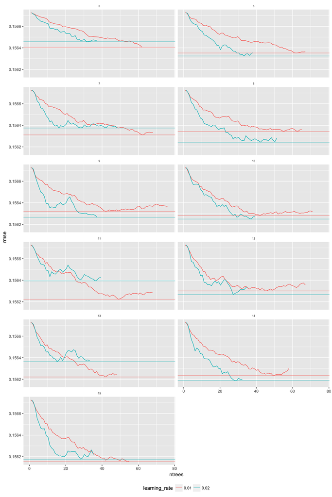

```r
min_y_lim = score.history %>% pull(rmse) %>% min
max_y_lim = score.history %>% pull(rmse) %>% max
score.history.t  = score.history%>% group_by(max_depth, learn_rate) %>%  mutate(min_rmse_by_depth =  min(rmse)) %>% ungroup

ggplot(score.history.t) +
    facet_wrap(~ max_depth, ncol=2) +
        geom_line(aes(y=rmse, x=ntrees,
                      color=as.factor(learn_rate)),
                  position=position_dodge(1)) +
        geom_hline(aes(yintercept = min_rmse_by_depth, color=as.factor(learn_rate)), size=0.6, alpha=0.5) +
        ylim(c(min_y_lim, max_y_lim)) +
        theme(
          legend.position="bottom",
          strip.background = element_blank(),
          strip.text.x = element_text(size=6)
        ) + guides(col=guide_legend(title="learning_rate", position="bottom"))
```